[figure not shown]

# Main Project: Robust Data Modeling with Ensembling and Tuning Techniques

# EasyVisa – Visa Application Status Prediction

## 0. Project Introduction

### 0.1 Business Context

Business communities in the United States face a high demand for skilled human resources. To meet workforce requirements, organizations recruit qualified and talented individuals from both the United States and abroad.

The Immigration and Nationality Act (INA) allows foreign workers to enter the United States for temporary or permanent employment. The Office of Foreign Labor Certification (OFLC) administers the relevant immigration programs and processes labor certification applications submitted by employers seeking to employ foreign workers.

The certification process is intended to ensure that sufficient U.S. workers are not available to perform the required work and that the employment of foreign workers does not adversely affect the wages and working conditions of U.S. workers.

As the number of applications continues to increase, manually reviewing every application becomes increasingly time-consuming and operationally challenging.

### 0.2 Business Problem

The increasing volume of visa applications creates a need for a data-driven approach that can help identify applications with a higher likelihood of visa certification.

EasyVisa has been engaged to analyze historical visa application data and develop a machine learning solution that can predict the outcome of a visa application.

The target variable for this analysis is:

**`case_status`**

which indicates whether a visa application was **Certified** or **Denied**.

### 0.3 Business Objective

The primary objectives of this project are:

1. To develop a classification model that can help facilitate the visa approval and certification process.
2. To identify the applicant and employer characteristics that significantly influence the visa case status.
3. To recommend suitable applicant profiles that are more likely to be certified or denied based on the important drivers identified through the analysis.
4. To support a more efficient and data-driven approach to processing the increasing volume of visa applications.

### 0.4 Analytical Objective

This project will be treated as a **binary classification problem**.

- **Target variable:** `case_status`
- **Possible outcomes:** Certified / Denied
- **Predictor variables:** Applicant and employer-related attributes provided in the dataset.

The analysis will include exploratory data analysis, data preprocessing, feature engineering, model development using decision tree, bagging, and boosting techniques, class-imbalance handling through oversampling and undersampling, and hyperparameter tuning.

### 0.5 Overall Approach

The project will follow the following analytical workflow:

**Business Understanding → Data Understanding → Exploratory Data Analysis → Data Preprocessing → Original Data Modeling → Oversampled Data Modeling → Undersampled Data Modeling → Hyperparameter Tuning → Model Comparison → Final Model Selection → Business Insights → Recommendations**

The final model will be evaluated on an untouched test dataset to assess its ability to generalize to unseen visa applications.

## 1. Data Understanding

### 1.1 Import Libraries and Load Dataset

```python
# Import required libraries
import pandas as pd
import numpy as np
import matplotlib.pyplot as plt
import seaborn as sns

# Display all columns
pd.set_option('display.max_columns', None)

from google.colab import drive
drive.mount('/content/drive')

# df = pd.read_csv("/content/drive/MyDrive/MainProject-2/EasyVisa.csv")
Visa_df = pd.read_csv("/content/drive/MyDrive/MainProject-2/EasyVisa.csv")
df = Visa_df

# Display the first five records
df.head()
```

|  | case_id | continent | education_of_employee | has_job_experience | requires_job_training | no_of_employees | yr_of_estab | region_of_employment | prevailing_wage | unit_of_wage | full_time_position | case_status |
| --- | --- | --- | --- | --- | --- | --- | --- | --- | --- | --- | --- | --- |
| 0 | EZYV01 | Asia | High School | N | N | 14513 | 2007 | West | 592.2029 | Hour | Y | Denied |
| 1 | EZYV02 | Asia | Master's | Y | N | 2412 | 2002 | Northeast | 83425.6500 | Year | Y | Certified |
| 2 | EZYV03 | Asia | Bachelor's | N | Y | 44444 | 2008 | West | 122996.8600 | Year | Y | Denied |
| 3 | EZYV04 | Asia | Bachelor's | N | N | 98 | 1897 | West | 83434.0300 | Year | Y | Denied |
| 4 | EZYV05 | Africa | Master's | Y | N | 1082 | 2005 | South | 149907.3900 | Year | Y | Certified |

### 1.2 Dataset Dimensions

```python
# Display number of rows and columns
print("Number of rows    :", df.shape[0])
print("Number of columns :", df.shape[1])
```

```
Number of rows    : 25480
Number of columns : 12
```

### 1.3 First 10 Records

```python
df.head(10)
```

|  | case_id | continent | education_of_employee | has_job_experience | requires_job_training | no_of_employees | yr_of_estab | region_of_employment | prevailing_wage | unit_of_wage | full_time_position | case_status |
| --- | --- | --- | --- | --- | --- | --- | --- | --- | --- | --- | --- | --- |
| 0 | EZYV01 | Asia | High School | N | N | 14513 | 2007 | West | 592.2029 | Hour | Y | Denied |
| 1 | EZYV02 | Asia | Master's | Y | N | 2412 | 2002 | Northeast | 83425.6500 | Year | Y | Certified |
| 2 | EZYV03 | Asia | Bachelor's | N | Y | 44444 | 2008 | West | 122996.8600 | Year | Y | Denied |
| 3 | EZYV04 | Asia | Bachelor's | N | N | 98 | 1897 | West | 83434.0300 | Year | Y | Denied |
| 4 | EZYV05 | Africa | Master's | Y | N | 1082 | 2005 | South | 149907.3900 | Year | Y | Certified |
| 5 | EZYV06 | Asia | Master's | Y | N | 2339 | 2012 | South | 78252.1400 | Year | Y | Certified |
| 6 | EZYV07 | Asia | Bachelor's | N | N | 4985 | 1994 | South | 53635.3900 | Year | Y | Certified |
| 7 | EZYV08 | North America | Bachelor's | Y | N | 3035 | 1924 | West | 418.2298 | Hour | Y | Denied |
| 8 | EZYV09 | Asia | Bachelor's | N | N | 4810 | 2012 | Midwest | 74362.1900 | Year | Y | Certified |
| 9 | EZYV10 | Europe | Doctorate | Y | N | 2251 | 1995 | South | 67514.7600 | Year | Y | Certified |

### 1.4 Last 10 Records

```python
df.tail(10)
```

|  | case_id | continent | education_of_employee | has_job_experience | requires_job_training | no_of_employees | yr_of_estab | region_of_employment | prevailing_wage | unit_of_wage | full_time_position | case_status |
| --- | --- | --- | --- | --- | --- | --- | --- | --- | --- | --- | --- | --- |
| 25470 | EZYV25471 | North America | Master's | Y | N | 2272 | 1970 | Northeast | 516.4101 | Hour | Y | Certified |
| 25471 | EZYV25472 | Asia | High School | N | N | 40224 | 1962 | Island | 75587.4200 | Year | Y | Certified |
| 25472 | EZYV25473 | Asia | High School | N | N | 1346 | 2003 | Midwest | 76155.6000 | Year | N | Certified |
| 25473 | EZYV25474 | Asia | Bachelor's | Y | N | 2421 | 2007 | Northeast | 22845.5600 | Year | Y | Certified |
| 25474 | EZYV25475 | Africa | Doctorate | N | N | 2594 | 1979 | Northeast | 51104.7800 | Year | Y | Certified |
| 25475 | EZYV25476 | Asia | Bachelor's | Y | Y | 2601 | 2008 | South | 77092.5700 | Year | Y | Certified |
| 25476 | EZYV25477 | Asia | High School | Y | N | 3274 | 2006 | Northeast | 279174.7900 | Year | Y | Certified |
| 25477 | EZYV25478 | Asia | Master's | Y | N | 1121 | 1910 | South | 146298.8500 | Year | N | Certified |
| 25478 | EZYV25479 | Asia | Master's | Y | Y | 1918 | 1887 | West | 86154.7700 | Year | Y | Certified |
| 25479 | EZYV25480 | Asia | Bachelor's | Y | N | 3195 | 1960 | Midwest | 70876.9100 | Year | Y | Certified |

### 1.5 Dataset Information and Data Types

```python
data_type_summary = pd.DataFrame({
    'Column': df.columns,
    'Data Type': df.dtypes.astype(str).values,
    'Non-Null Count': df.notnull().sum().values,
    'Missing Values': df.isnull().sum().values
})

data_type_summary
```

|  | Column | Data Type | Non-Null Count | Missing Values |
| --- | --- | --- | --- | --- |
| 0 | case_id | object | 25480 | 0 |
| 1 | continent | object | 25480 | 0 |
| 2 | education_of_employee | object | 25480 | 0 |
| 3 | has_job_experience | object | 25480 | 0 |
| 4 | requires_job_training | object | 25480 | 0 |
| 5 | no_of_employees | int64 | 25480 | 0 |
| 6 | yr_of_estab | int64 | 25480 | 0 |
| 7 | region_of_employment | object | 25480 | 0 |
| 8 | prevailing_wage | float64 | 25480 | 0 |
| 9 | unit_of_wage | object | 25480 | 0 |
| 10 | full_time_position | object | 25480 | 0 |
| 11 | case_status | object | 25480 | 0 |

### 1.6 Data Dictionary

| Variable | Description | Data Type / Role |
| --- | --- | --- |
| case_id | Unique identifier of each visa application | Identifier |
| continent | Continent of the employee | Categorical |
| education_of_employee | Education level of the employee | Categorical |
| has_job_experience | Indicates whether the employee has previous job experience | Categorical |
| requires_job_training | Indicates whether the employee requires job training | Categorical |
| no_of_employees | Number of employees in the employer's company | Numerical |
| yr_of_estab | Year in which the employer's company was established | Numerical |
| region_of_employment | Intended region of employment in the US | Categorical |
| prevailing_wage | Average wage paid to similarly employed workers in the specified occupation and area | Numerical |
| unit_of_wage | Unit of the prevailing wage | Categorical |
| full_time_position | Indicates whether the position is full-time | Categorical |
| case_status | Visa application outcome: Certified or Denied | Target |

### 1.7 Identify Numerical and Categorical Variables

```python
# Identify numerical and categorical columns
numerical_columns = df.select_dtypes(include=np.number).columns.tolist()
categorical_columns = df.select_dtypes(exclude=np.number).columns.tolist()

print("Numerical Variables:")
print(numerical_columns)

print("\nCategorical Variables:")
print(categorical_columns)
```

```
Numerical Variables:
['no_of_employees', 'yr_of_estab', 'prevailing_wage']

Categorical Variables:
['case_id', 'continent', 'education_of_employee', 'has_job_experience', 'requires_job_training', 'region_of_employment', 'unit_of_wage', 'full_time_position', 'case_status']
```

### 1.8 Unique Values

```python
for col in categorical_columns:
    print(f"\n{'='*60}")
    print(f"Column: {col}")
    print(f"Number of unique values: {df[col].nunique(dropna=False)}")
    print(df[col].value_counts(dropna=False))
```

```
============================================================
Column: case_id
Number of unique values: 25480
case_id
EZYV25480    1
EZYV01       1
EZYV02       1
EZYV03       1
EZYV04       1
            ..
EZYV13       1
EZYV12       1
EZYV11       1
EZYV10       1
EZYV09       1
Name: count, Length: 25480, dtype: int64

============================================================
Column: continent
Number of unique values: 6
continent
Asia             16861
Europe            3732
North America     3292
South America      852
Africa             551
Oceania            192
Name: count, dtype: int64

============================================================
Column: education_of_employee
Number of unique values: 4
education_of_employee
Bachelor's     10234
Master's        9634
High School     3420
Doctorate       2192
Name: count, dtype: int64

============================================================
```

[output cut: 36 more lines]

```
============================================================
Column: full_time_position
Number of unique values: 2
full_time_position
Y    22773
N     2707
Name: count, dtype: int64

============================================================
Column: case_status
Number of unique values: 2
case_status
Certified    17018
Denied        8462
Name: count, dtype: int64
```

### 1.9 Statistical Summary — Numerical Variables

```python
df[numerical_columns].describe().T
```

|  | count | mean | std | min | 25% | 50% | 75% | max |
| --- | --- | --- | --- | --- | --- | --- | --- | --- |
| no_of_employees | 25480.0 | 5667.043210 | 22877.928848 | -26.0000 | 1022.00 | 2109.00 | 3504.0000 | 602069.00 |
| yr_of_estab | 25480.0 | 1979.409929 | 42.366929 | 1800.0000 | 1976.00 | 1997.00 | 2005.0000 | 2016.00 |
| prevailing_wage | 25480.0 | 74455.814592 | 52815.942327 | 2.1367 | 34015.48 | 70308.21 | 107735.5125 | 319210.27 |

### 1.10 Statistical Summary — Categorical Variables

```python
df[categorical_columns].describe().T
```

|  | count | unique | top | freq |
| --- | --- | --- | --- | --- |
| case_id | 25480 | 25480 | EZYV25480 | 1 |
| continent | 25480 | 6 | Asia | 16861 |
| education_of_employee | 25480 | 4 | Bachelor's | 10234 |
| has_job_experience | 25480 | 2 | Y | 14802 |
| requires_job_training | 25480 | 2 | N | 22525 |
| region_of_employment | 25480 | 5 | Northeast | 7195 |
| unit_of_wage | 25480 | 4 | Year | 22962 |
| full_time_position | 25480 | 2 | Y | 22773 |
| case_status | 25480 | 2 | Certified | 17018 |

### 1.11 Duplicate Records

```python
duplicate_count = df.duplicated().sum()

print("Number of duplicate rows:", duplicate_count)
```

```
Number of duplicate rows: 0
```

```python
duplicate_percentage = (duplicate_count / len(df)) * 100

print(f"Duplicate percentage: {duplicate_percentage:.2f}%")
```

```
Duplicate percentage: 0.00%
```

### 1.12 Missing Value Analysis

```python
missing_summary = pd.DataFrame({
    'Missing Count': df.isnull().sum(),
    'Missing Percentage': (df.isnull().sum() / len(df)) * 100
})

missing_summary = missing_summary[
    missing_summary['Missing Count'] > 0
].sort_values(
    by='Missing Percentage',
    ascending=False
)

missing_summary
```

|  | Missing Count | Missing Percentage |
| --- | --- | --- |

#### Visualization

```python
missing_counts = df.isnull().sum()

missing_counts = missing_counts[missing_counts > 0]

if len(missing_counts) > 0:
    plt.figure(figsize=(10, 5))
    missing_counts.sort_values(ascending=False).plot(kind='bar')
    plt.title('Missing Values by Variable')
    plt.xlabel('Variables')
    plt.ylabel('Number of Missing Values')
    plt.xticks(rotation=45)
    plt.tight_layout()
    plt.show()
else:
    print("No missing values found in the dataset.")
```

```
No missing values found in the dataset.
```

### 1.13 Target Variable — case_status

```python
# Target variable frequency
case_status_counts = df['case_status'].value_counts()

print(case_status_counts)
```

```
case_status
Certified    17018
Denied        8462
Name: count, dtype: int64
```

```python
case_status_percentage = (
    df['case_status']
    .value_counts(normalize=True)
    .mul(100)
    .round(2)
)

print(case_status_percentage)
```

```
case_status
Certified    66.79
Denied       33.21
Name: proportion, dtype: float64
```

### 1.14 Target Variable Visualization

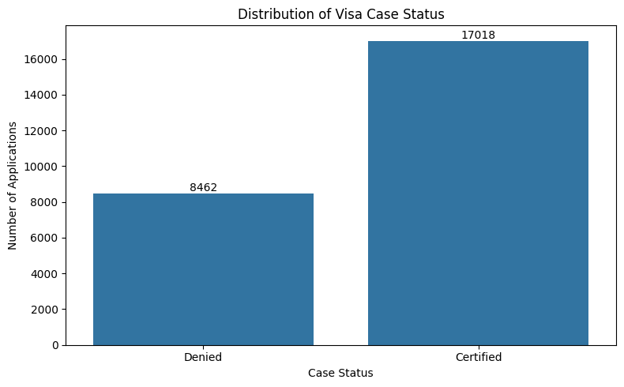

```python
plt.figure(figsize=(8, 5))

ax = sns.countplot(
    data=df,
    x='case_status'
)

plt.title('Distribution of Visa Case Status')
plt.xlabel('Case Status')
plt.ylabel('Number of Applications')

# Add count labels
for container in ax.containers:
    ax.bar_label(container)

plt.tight_layout()
plt.show()
```

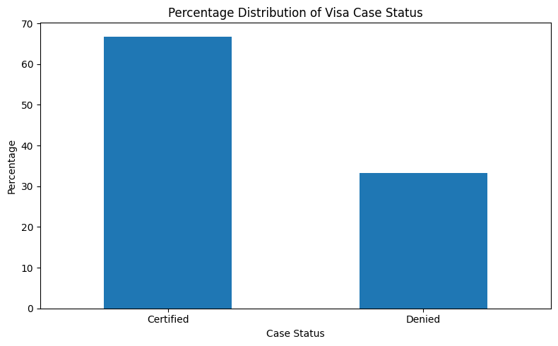

```python
plt.figure(figsize=(8, 5))

case_status_percentage.plot(
    kind='bar'
)

plt.title('Percentage Distribution of Visa Case Status')
plt.xlabel('Case Status')
plt.ylabel('Percentage')

plt.xticks(rotation=0)
plt.tight_layout()
plt.show()
```

### 1.15 Target Class Imbalance

```python
target_counts = df['case_status'].value_counts()

majority_class = target_counts.idxmax()
minority_class = target_counts.idxmin()

majority_count = target_counts.max()
minority_count = target_counts.min()

imbalance_ratio = majority_count / minority_count

print("Majority class :", majority_class)
print("Majority count :", majority_count)
print("Minority class :", minority_class)
print("Minority count :", minority_count)
print(f"Imbalance ratio: {imbalance_ratio:.2f}")
```

```
Majority class : Certified
Majority count : 17018
Minority class : Denied
Minority count : 8462
Imbalance ratio: 2.01
```

### 1.16 Data Understanding — Initial Findings

# 2. Exploratory Data Analysis

## 2.1 Univariate Analysis — Numerical Variables

### 2.1.1 Distribution of Number of Employees

The `no_of_employees` variable represents the number of employees working in the employer's organization.

The distribution is examined to understand its central tendency, spread, skewness, and presence of extreme observations.

```python
# Summary statistics
df['no_of_employees'].describe()
```

|  | no_of_employees |
| --- | --- |
| count | 25480.000000 |
| mean | 5667.043210 |
| std | 22877.928848 |
| min | -26.000000 |
| 25% | 1022.000000 |
| 50% | 2109.000000 |
| 75% | 3504.000000 |
| max | 602069.000000 |

**dtype:** float64

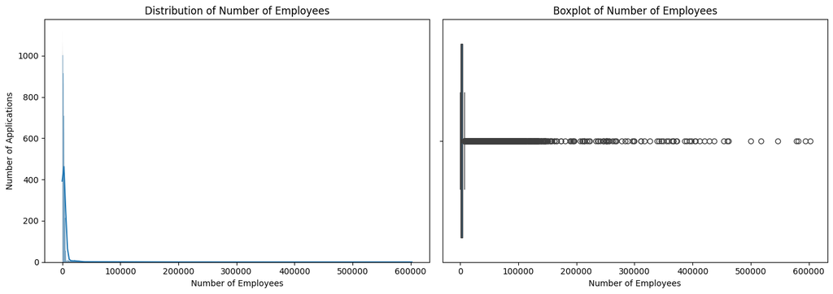

```python
fig, axes = plt.subplots(1, 2, figsize=(14, 5))

# Histogram
sns.histplot(
    data=df,
    x='no_of_employees',
    kde=True,
    ax=axes[0]
)
axes[0].set_title('Distribution of Number of Employees')
axes[0].set_xlabel('Number of Employees')
axes[0].set_ylabel('Number of Applications')

# Boxplot
sns.boxplot(
    data=df,
    x='no_of_employees',
    ax=axes[1]
)
axes[1].set_title('Boxplot of Number of Employees')
axes[1].set_xlabel('Number of Employees')

plt.tight_layout()
plt.show()
```

#### Observation cell

**Observation:**

The distribution of `no_of_employees` is examined for its central tendency, spread, skewness, and extreme observations. The histogram and boxplot indicate whether the variable is concentrated within a particular range and whether unusually large values are present.

These characteristics will be considered during the data preprocessing and outlier analysis stage.

### 2.1.2 Distribution of Employer Establishment Year

The `yr_of_estab` variable indicates the year in which the employer's company was established. Its distribution helps understand the age profile of organizations sponsoring visa applications.

```python
df['yr_of_estab'].describe()
```

|  | yr_of_estab |
| --- | --- |
| count | 25480.000000 |
| mean | 1979.409929 |
| std | 42.366929 |
| min | 1800.000000 |
| 25% | 1976.000000 |
| 50% | 1997.000000 |
| 75% | 2005.000000 |
| max | 2016.000000 |

**dtype:** float64

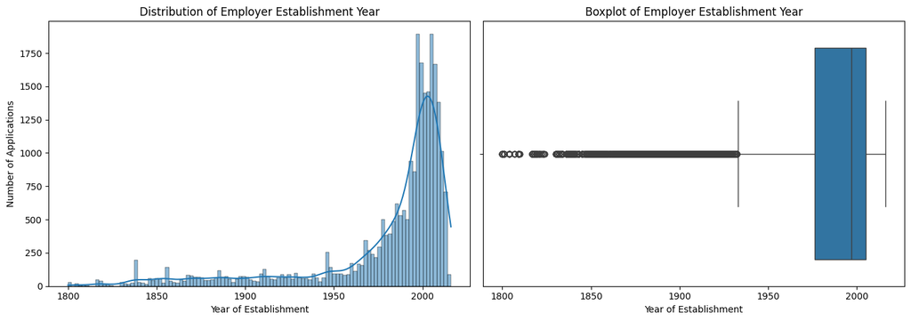

```python
fig, axes = plt.subplots(1, 2, figsize=(14, 5))

sns.histplot(
    data=df,
    x='yr_of_estab',
    kde=True,
    ax=axes[0]
)
axes[0].set_title('Distribution of Employer Establishment Year')
axes[0].set_xlabel('Year of Establishment')
axes[0].set_ylabel('Number of Applications')

sns.boxplot(
    data=df,
    x='yr_of_estab',
    ax=axes[1]
)
axes[1].set_title('Boxplot of Employer Establishment Year')
axes[1].set_xlabel('Year of Establishment')

plt.tight_layout()
plt.show()
```

**Observation:**

The distribution of employer establishment years provides an overview of the organizations represented in the dataset. The concentration of observations and the spread of establishment years will help us understand whether the dataset contains employers with a wide range of organizational ages.

### 2.1.3 Distribution of Prevailing Wage

`prevailing_wage` represents the average wage paid to similarly employed workers in a specific occupation and geographical area.

The distribution is analyzed to understand its range, concentration, skewness, and potential extreme observations.

```python
df['prevailing_wage'].describe()
```

|  | prevailing_wage |
| --- | --- |
| count | 25480.000000 |
| mean | 74455.814592 |
| std | 52815.942327 |
| min | 2.136700 |
| 25% | 34015.480000 |
| 50% | 70308.210000 |
| 75% | 107735.512500 |
| max | 319210.270000 |

**dtype:** float64

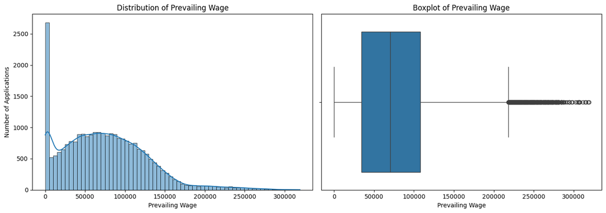

```python
fig, axes = plt.subplots(1, 2, figsize=(14, 5))

sns.histplot(
    data=df,
    x='prevailing_wage',
    kde=True,
    ax=axes[0]
)
axes[0].set_title('Distribution of Prevailing Wage')
axes[0].set_xlabel('Prevailing Wage')
axes[0].set_ylabel('Number of Applications')

sns.boxplot(
    data=df,
    x='prevailing_wage',
    ax=axes[1]
)
axes[1].set_title('Boxplot of Prevailing Wage')
axes[1].set_xlabel('Prevailing Wage')

plt.tight_layout()
plt.show()
```

**Observation:**

The distribution of `prevailing_wage` is examined to identify its typical range and dispersion. The histogram and boxplot also help identify potential extreme wage observations. These observations will be investigated further during the data preprocessing stage rather than being removed solely based on their appearance.

## 2.2 Univariate Analysis — Categorical Variables

### 2.2.1 Create a Count Plot Function

```python
def plot_categorical_distribution(data, column, figsize=(10, 5)):
    plt.figure(figsize=figsize)

    ax = sns.countplot(
        data=data,
        x=column,
        order=data[column].value_counts().index
    )

    plt.title(f'Distribution of {column}')
    plt.xlabel(column.replace('_', ' ').title())
    plt.ylabel('Number of Applications')
    plt.xticks(rotation=45, ha='right')

    for container in ax.containers:
        ax.bar_label(container, fontsize=9)

    plt.tight_layout()
    plt.show()
```

### 2.2.2 Continent

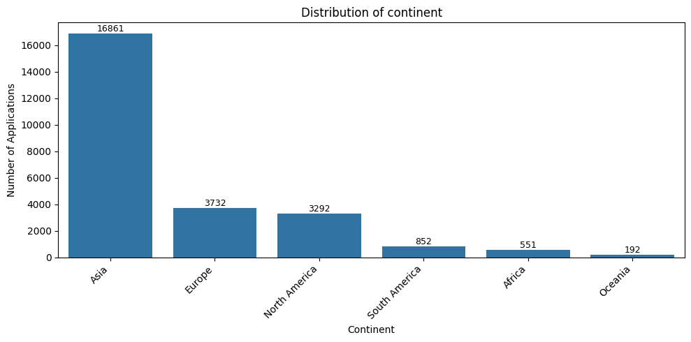

```python
plot_categorical_distribution(
    df,
    'continent',
    figsize=(10, 5)
)
```

**Observation:**

The distribution of visa applications varies across continents. The count plot helps identify the continents contributing the largest and smallest number of applications in the dataset. This distribution will be examined further against `case_status` during bivariate analysis.

2.2.3 Education of Employee

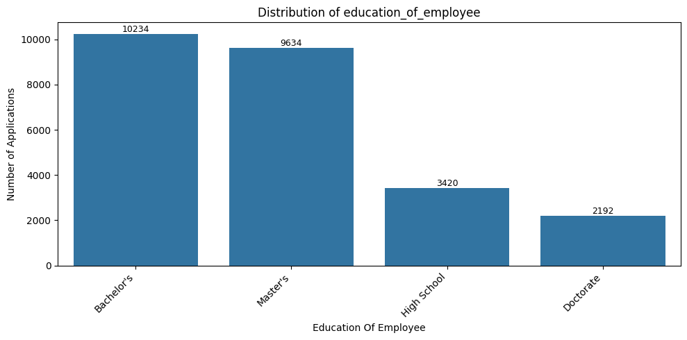

```python
plot_categorical_distribution(
    df,
    'education_of_employee',
    figsize=(10, 5)
)
```

**Observation:**

The distribution shows the representation of different education levels among visa applicants. This variable is particularly relevant to the business problem because employee qualifications may be associated with the outcome of a visa application.

### 2.2.4 Distribution of Job Experience

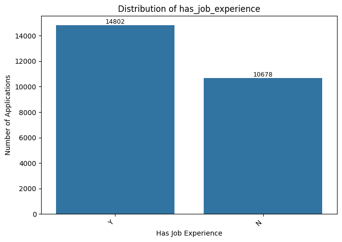

```python
plot_categorical_distribution(
    df,
    'has_job_experience',
    figsize=(7, 5)
)
```

### 2.2.5 Distribution of Job Training Requirement

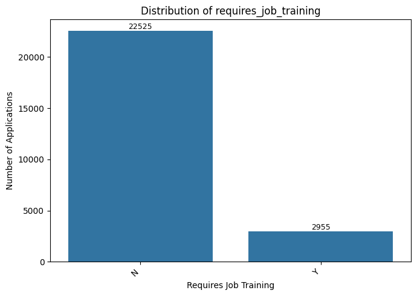

```python
plot_categorical_distribution(
    df,
    'requires_job_training',
    figsize=(7, 5)
)
```

### 2.2.6 Distribution of Region of Employment

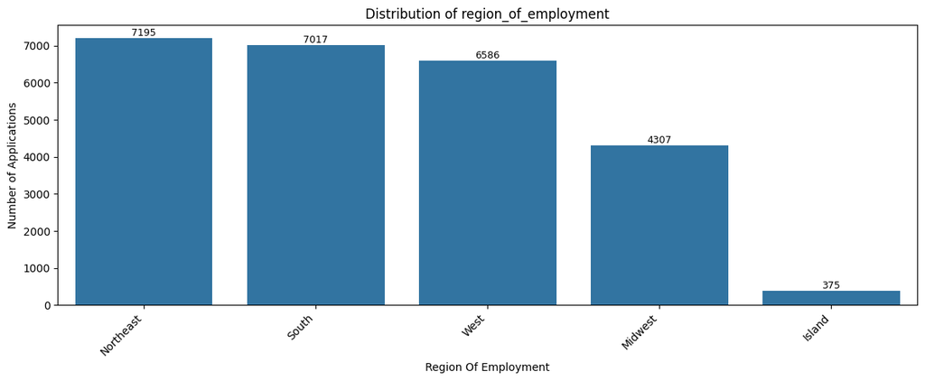

```python
plot_categorical_distribution(
    df,
    'region_of_employment',
    figsize=(12, 5)
)
```

### 2.2.7 Distribution of Wage Unit

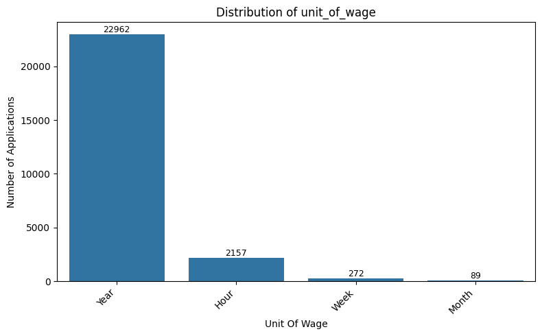

```python
plot_categorical_distribution(
    df,
    'unit_of_wage',
    figsize=(8, 5)
)
```

### 2.2.8 Distribution of Full-Time Position

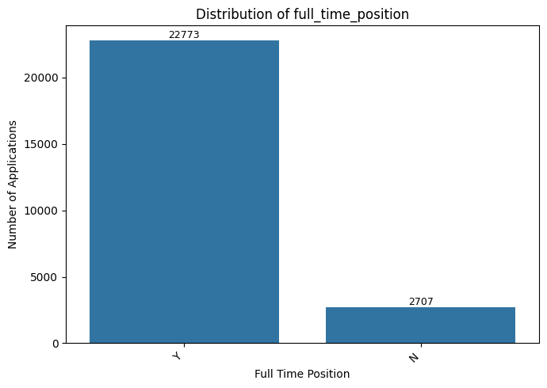

```python
plot_categorical_distribution(
    df,
    'full_time_position',
    figsize=(7, 5)
)
```

## 2.3 Bivariate Analysis — Numerical Variables vs Case Status

### 2.3.1 Number of Employees vs Visa Case Status

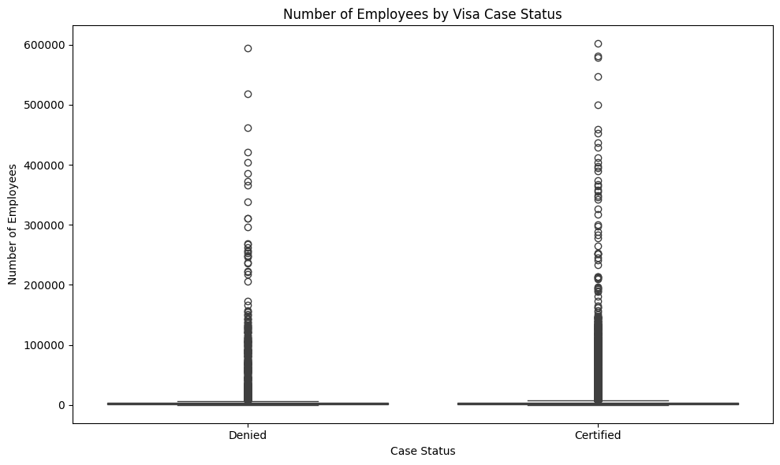

```python
plt.figure(figsize=(10, 6))

sns.boxplot(
    data=df,
    x='case_status',
    y='no_of_employees'
)

plt.title('Number of Employees by Visa Case Status')
plt.xlabel('Case Status')
plt.ylabel('Number of Employees')

plt.tight_layout()
plt.show()
```

```python
df.groupby('case_status')['no_of_employees'].agg(
    ['count', 'mean', 'median', 'std', 'min', 'max']
).round(2)
```

| case_status | count | mean | median | std | min | max |
| --- | --- | --- | --- | --- | --- | --- |
| Certified | 17018 | 5807.02 | 2147.0 | 23119.58 | -26 | 602069 |
| Denied | 8462 | 5385.54 | 2032.5 | 22382.76 | -26 | 594472 |

**Observation:**

The boxplot and summary statistics compare the distribution of employer size across Certified and Denied applications. Differences in the median, spread, or extreme values may indicate whether employer size is associated with the visa case outcome.

The observed relationship is associative and does not imply that employer size directly causes certification or denial.

### 2.3.2 Employer Establishment Year vs Case Status

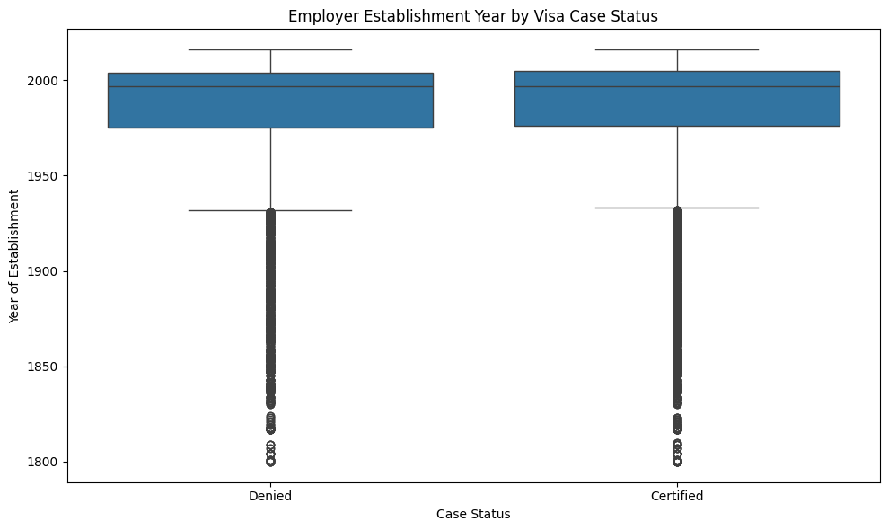

```python
plt.figure(figsize=(10, 6))

sns.boxplot(
    data=df,
    x='case_status',
    y='yr_of_estab'
)

plt.title('Employer Establishment Year by Visa Case Status')
plt.xlabel('Case Status')
plt.ylabel('Year of Establishment')

plt.tight_layout()
plt.show()
```

```python
df.groupby('case_status')['yr_of_estab'].agg(
    ['count', 'mean', 'median', 'std', 'min', 'max']
).round(2)
```

| case_status | count | mean | median | std | min | max |
| --- | --- | --- | --- | --- | --- | --- |
| Certified | 17018 | 1979.67 | 1997.0 | 42.28 | 1800 | 2016 |
| Denied | 8462 | 1978.89 | 1997.0 | 42.54 | 1800 | 2016 |

### 2.3.3 Prevailing Wage vs Case Status

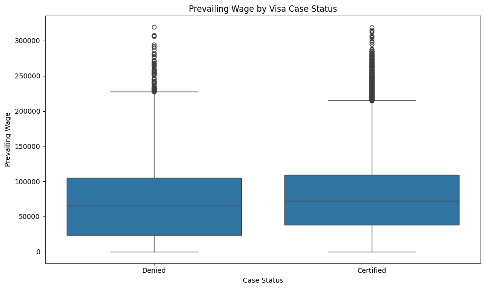

```python
plt.figure(figsize=(10, 6))

sns.boxplot(
    data=df,
    x='case_status',
    y='prevailing_wage'
)

plt.title('Prevailing Wage by Visa Case Status')
plt.xlabel('Case Status')
plt.ylabel('Prevailing Wage')

plt.tight_layout()
plt.show()
```

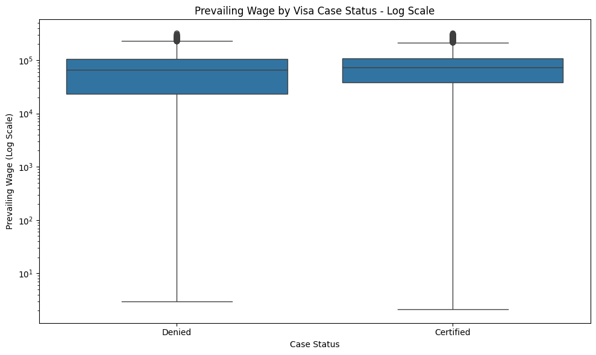

```python
plt.figure(figsize=(10, 6))

sns.boxplot(
    data=df,
    x='case_status',
    y='prevailing_wage'
)

plt.yscale('log')

plt.title('Prevailing Wage by Visa Case Status - Log Scale')
plt.xlabel('Case Status')
plt.ylabel('Prevailing Wage (Log Scale)')

plt.tight_layout()
plt.show()
```

## 2.4 Bivariate Analysis — Categorical Variables vs Case Status

### 2.4.1 Create a Percentage Plot Function

```python
def plot_categorical_vs_target(data, feature, target='case_status', figsize=(10, 6)):
    percentage_table = pd.crosstab(
        data[feature],
        data[target],
        normalize='index'
    ) * 100

    percentage_table = percentage_table.sort_values(
        by=percentage_table.columns.tolist(),
        ascending=False
    )

    ax = percentage_table.plot(
        kind='bar',
        stacked=True,
        figsize=figsize
    )

    plt.title(f'{feature.replace("_", " ").title()} vs {target.replace("_", " ").title()}')
    plt.xlabel(feature.replace('_', ' ').title())
    plt.ylabel('Percentage of Applications')
    plt.xticks(rotation=45, ha='right')
    plt.legend(title=target.replace('_', ' ').title())

    plt.tight_layout()
    plt.show()

    return percentage_table.round(2)
```

### 2.4.2 Continent vs Case Status

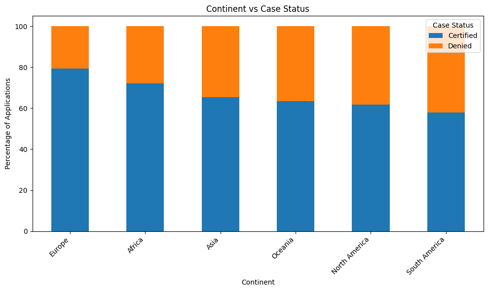

| case_status continent | Certified | Denied |
| --- | --- | --- |
| Europe | 79.23 | 20.77 |
| Africa | 72.05 | 27.95 |
| Asia | 65.31 | 34.69 |
| Oceania | 63.54 | 36.46 |
| North America | 61.88 | 38.12 |
| South America | 57.86 | 42.14 |

```python
continent_status = plot_categorical_vs_target(
    df,
    'continent',
    'case_status',
    figsize=(10, 6)
)

continent_status
```

### 2.4.3 Education Level vs Visa Case Status

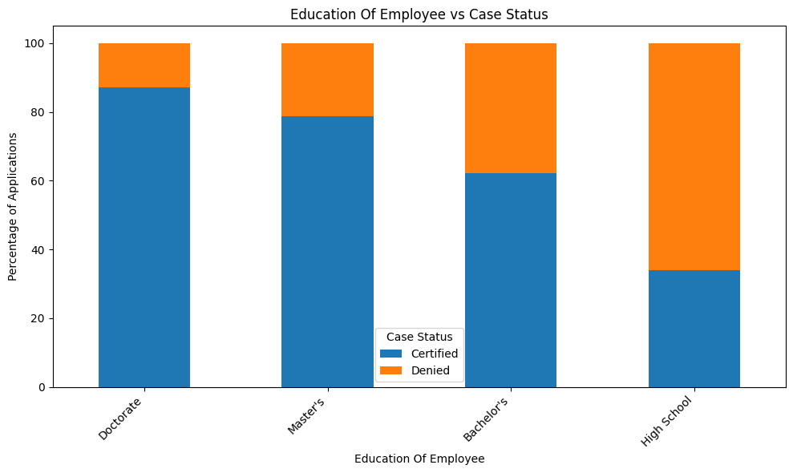

| case_status education_of_employee | Certified | Denied |
| --- | --- | --- |
| Doctorate | 87.23 | 12.77 |
| Master's | 78.63 | 21.37 |
| Bachelor's | 62.21 | 37.79 |
| High School | 34.04 | 65.96 |

```python
education_status = plot_categorical_vs_target(
    df,
    'education_of_employee',
    'case_status',
    figsize=(10, 6)
)

education_status
```

### 2.4.4 Job Experience vs Visa Case Status

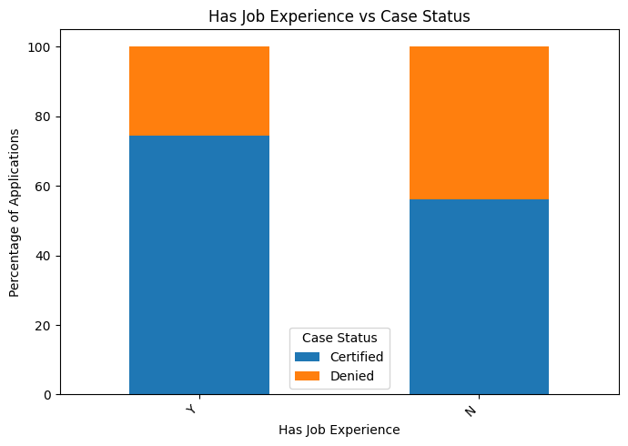

| case_status has_job_experience | Certified | Denied |
| --- | --- | --- |
| Y | 74.48 | 25.52 |
| N | 56.13 | 43.87 |

```python
experience_status = plot_categorical_vs_target(
    df,
    'has_job_experience',
    'case_status',
    figsize=(7, 5)
)

experience_status
```

### 2.4.5 Job Training Requirement vs Visa Case Status

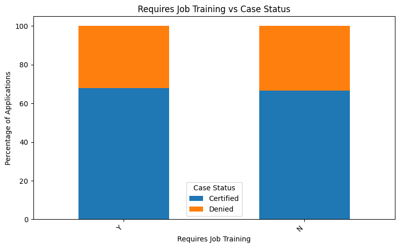

| case_status requires_job_training | Certified | Denied |
| --- | --- | --- |
| Y | 67.88 | 32.12 |
| N | 66.65 | 33.35 |

```python
training_status = plot_categorical_vs_target(
    df,
    'requires_job_training',
    'case_status',
    figsize=(8, 5)
)

training_status
```

### 2.4.6 Region of Employment vs Visa Case Status

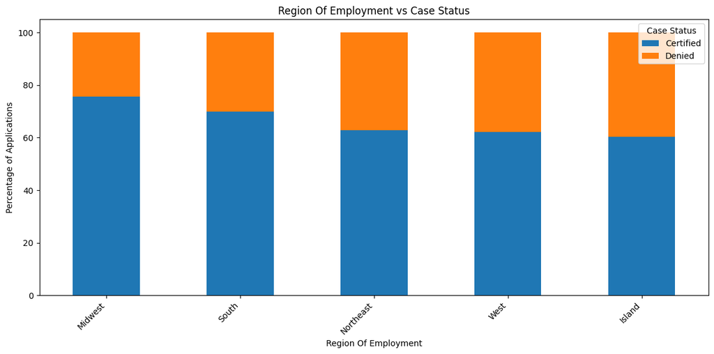

| case_status region_of_employment | Certified | Denied |
| --- | --- | --- |
| Midwest | 75.53 | 24.47 |
| South | 70.02 | 29.98 |
| Northeast | 62.90 | 37.10 |
| West | 62.25 | 37.75 |
| Island | 60.27 | 39.73 |

```python
region_status = plot_categorical_vs_target(
    df,
    'region_of_employment',
    'case_status',
    figsize=(12, 6)
)

region_status
```

### 2.4.7 Unit of Wage vs Visa Case Status

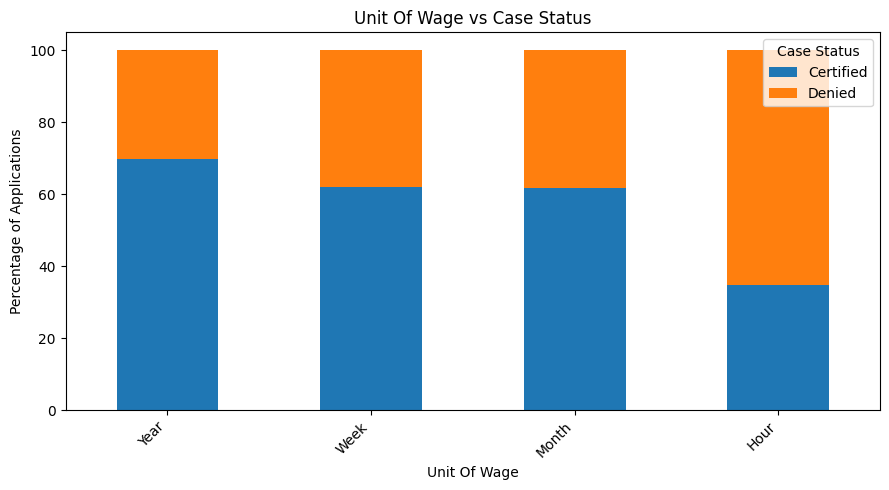

| case_status unit_of_wage | Certified | Denied |
| --- | --- | --- |
| Year | 69.89 | 30.11 |
| Week | 62.13 | 37.87 |
| Month | 61.80 | 38.20 |
| Hour | 34.63 | 65.37 |

```python
wage_unit_status = plot_categorical_vs_target(
    df,
    'unit_of_wage',
    'case_status',
    figsize=(9, 5)
)

wage_unit_status
```

### 2.4.8 Full-Time Position vs Visa Case Status

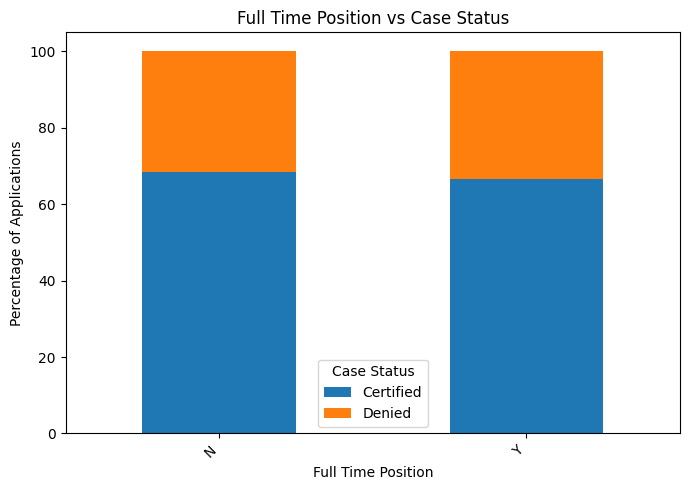

| case_status full_time_position | Certified | Denied |
| --- | --- | --- |
| N | 68.53 | 31.47 |
| Y | 66.58 | 33.42 |

```python
fulltime_status = plot_categorical_vs_target(
    df,
    'full_time_position',
    'case_status',
    figsize=(7, 5)
)

fulltime_status
```

## 2.5 Key EDA Relationships

### 2.5.1 Education + Job Experience + Case Status

```python
education_experience = pd.crosstab(
    [df['education_of_employee'], df['has_job_experience']],
    df['case_status'],
    normalize='index'
) * 100

education_experience.round(2)
```

| education_of_employee | case_status has_job_experience | Certified | Denied |
| --- | --- | --- | --- |
| Bachelor's | N | 51.31 | 48.69 |
|  | Y | 70.27 | 29.73 |
| Doctorate | N | 80.13 | 19.87 |
|  | Y | 92.57 | 7.43 |
| High School | N | 31.66 | 68.34 |
|  | Y | 35.67 | 64.33 |
| Master's | N | 64.29 | 35.71 |
|  | Y | 88.78 | 11.22 |

#### Visualization:

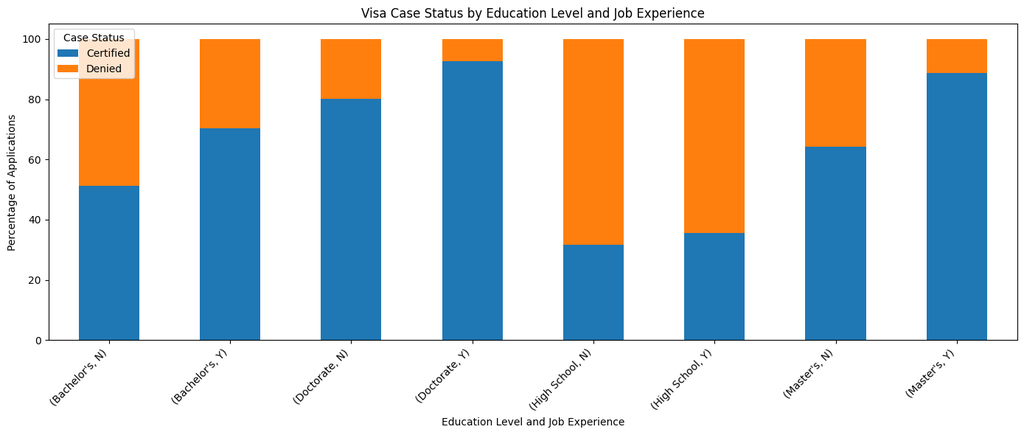

```python
education_experience.plot(
    kind='bar',
    stacked=True,
    figsize=(14, 6)
)

plt.title('Visa Case Status by Education Level and Job Experience')
plt.xlabel('Education Level and Job Experience')
plt.ylabel('Percentage of Applications')
plt.xticks(rotation=45, ha='right')
plt.legend(title='Case Status')

plt.tight_layout()
plt.show()
```

### 2.5.2 Wage Unit + Case Status

```python
wage_unit_summary = df.groupby(
    ['unit_of_wage', 'case_status']
)['prevailing_wage'].agg(
    ['count', 'mean', 'median']
).round(2)

wage_unit_summary
```

| unit_of_wage | case_status | count | mean | median |
| --- | --- | --- | --- | --- |
| Hour | Certified | 747 | 424.92 | 376.67 |
|  | Denied | 1410 | 409.09 | 367.79 |
| Month | Certified | 55 | 87237.55 | 81826.01 |
|  | Denied | 34 | 88167.63 | 78924.04 |
| Week | Certified | 169 | 85974.77 | 85297.78 |
|  | Denied | 103 | 85003.10 | 82042.03 |
| Year | Certified | 16047 | 80746.41 | 75427.84 |
|  | Denied | 6915 | 82345.84 | 77697.21 |

### 2.5.3 Correlation Analysis — Numerical Variables

```python
numeric_corr = df[
    ['no_of_employees', 'yr_of_estab', 'prevailing_wage']
].corr()

numeric_corr
```

|  | no_of_employees | yr_of_estab | prevailing_wage |
| --- | --- | --- | --- |
| no_of_employees | 1.000000 | -0.017770 | -0.009523 |
| yr_of_estab | -0.017770 | 1.000000 | 0.012342 |
| prevailing_wage | -0.009523 | 0.012342 | 1.000000 |

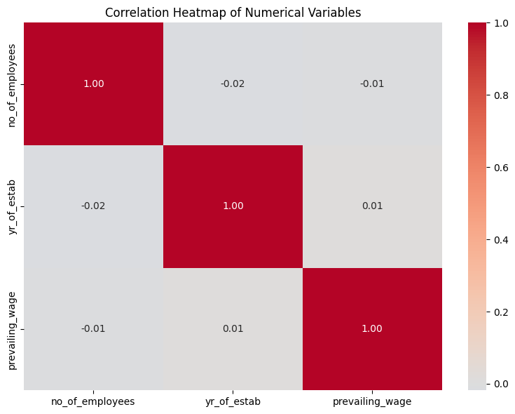

```python
plt.figure(figsize=(8, 6))

sns.heatmap(
    numeric_corr,
    annot=True,
    fmt='.2f',
    cmap='coolwarm',
    center=0
)

plt.title('Correlation Heatmap of Numerical Variables')
plt.tight_layout()
plt.show()
```

## 2.6 Key EDA Findings

# 3. Bivariate Analysis

## 3.1 Numerical Variables vs Case Status

### 3.1.1 Number of Employees vs Case Status

```python
# Compare number of employees across case status
df.groupby('case_status')['no_of_employees'].agg(
    ['count', 'mean', 'median', 'std', 'min', 'max']
).round(2)
```

| case_status | count | mean | median | std | min | max |
| --- | --- | --- | --- | --- | --- | --- |
| Certified | 17018 | 5807.02 | 2147.0 | 23119.58 | -26 | 602069 |
| Denied | 8462 | 5385.54 | 2032.5 | 22382.76 | -26 | 594472 |

#### Visualization

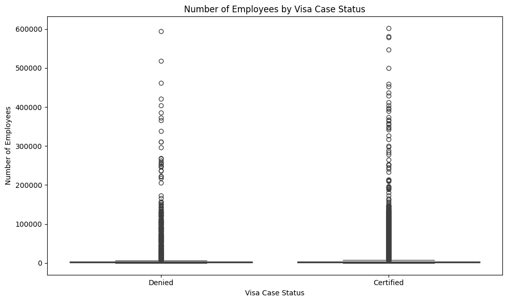

```python
plt.figure(figsize=(10, 6))

sns.boxplot(
    data=df,
    x='case_status',
    y='no_of_employees'
)

plt.title('Number of Employees by Visa Case Status')
plt.xlabel('Visa Case Status')
plt.ylabel('Number of Employees')

plt.tight_layout()
plt.show()
```

Because employee count may be highly skewed, also inspect the log-transformed visualization:

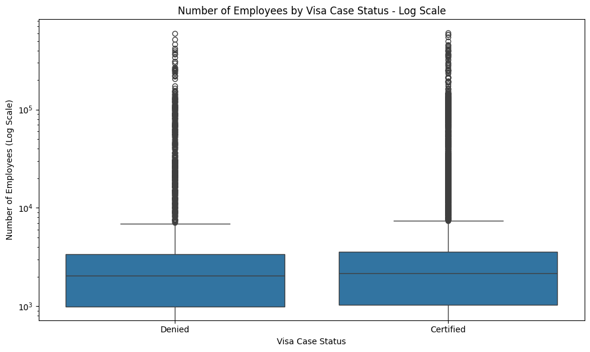

```python
plt.figure(figsize=(10, 6))

sns.boxplot(
    data=df,
    x='case_status',
    y='no_of_employees'
)

plt.yscale('log')

plt.title('Number of Employees by Visa Case Status - Log Scale')
plt.xlabel('Visa Case Status')
plt.ylabel('Number of Employees (Log Scale)')

plt.tight_layout()
plt.show()
```

**Observation:**

The distribution of `no_of_employees` across Certified and Denied cases is compared using the median, spread, and overall distribution.

This indicates that employer size may have an association with visa case status; however, this analysis does not establish a causal relationship.

### 3.1.2 Employer Establishment Year vs Case Status

The year in which the employer's company was established is analyzed against visa case status to examine whether the age of the employer appears to differ between Certified and Denied applications.

```python
df.groupby('case_status')['yr_of_estab'].agg(
    ['count', 'mean', 'median', 'std', 'min', 'max']
).round(2)
```

| case_status | count | mean | median | std | min | max |
| --- | --- | --- | --- | --- | --- | --- |
| Certified | 17018 | 1979.67 | 1997.0 | 42.28 | 1800 | 2016 |
| Denied | 8462 | 1978.89 | 1997.0 | 42.54 | 1800 | 2016 |

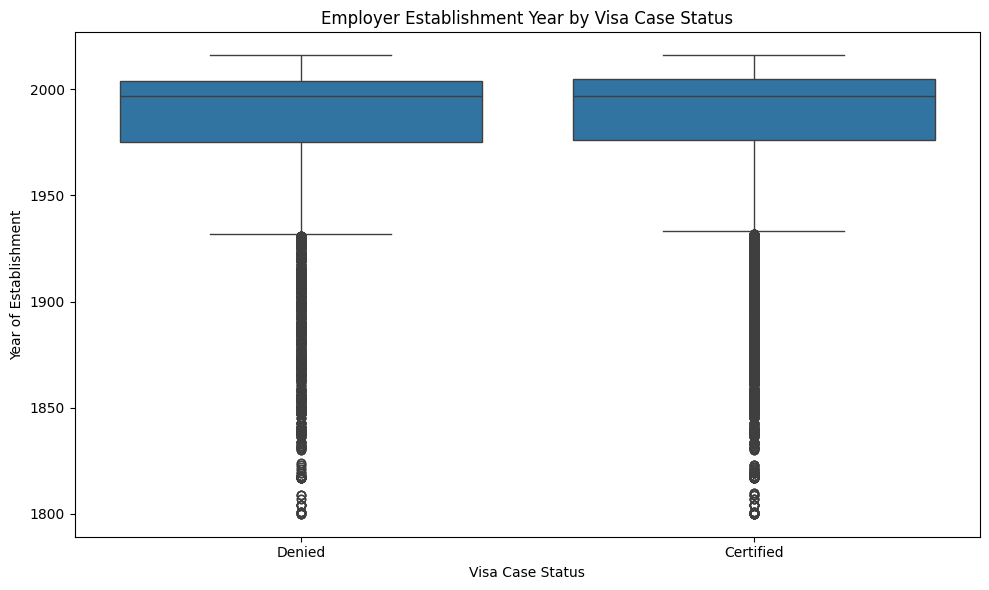

```python
plt.figure(figsize=(10, 6))

sns.boxplot(
    data=df,
    x='case_status',
    y='yr_of_estab'
)

plt.title('Employer Establishment Year by Visa Case Status')
plt.xlabel('Visa Case Status')
plt.ylabel('Year of Establishment')

plt.tight_layout()
plt.show()
```

**Observation:**

The boxplot compares the establishment year of employers across visa case-status groups.

### 3.1.3 Prevailing Wage vs Case Status

The prevailing wage is compared across Certified and Denied applications to identify whether differences in wage levels are associated with visa case status.

```python
df.groupby('case_status')['prevailing_wage'].agg(
    ['count', 'mean', 'median', 'std', 'min', 'max']
).round(2)
```

| case_status | count | mean | median | std | min | max |
| --- | --- | --- | --- | --- | --- | --- |
| Certified | 17018 | 77293.62 | 72486.27 | 52042.72 | 2.14 | 318446.05 |
| Denied | 8462 | 68748.68 | 65431.46 | 53890.17 | 2.96 | 319210.27 |

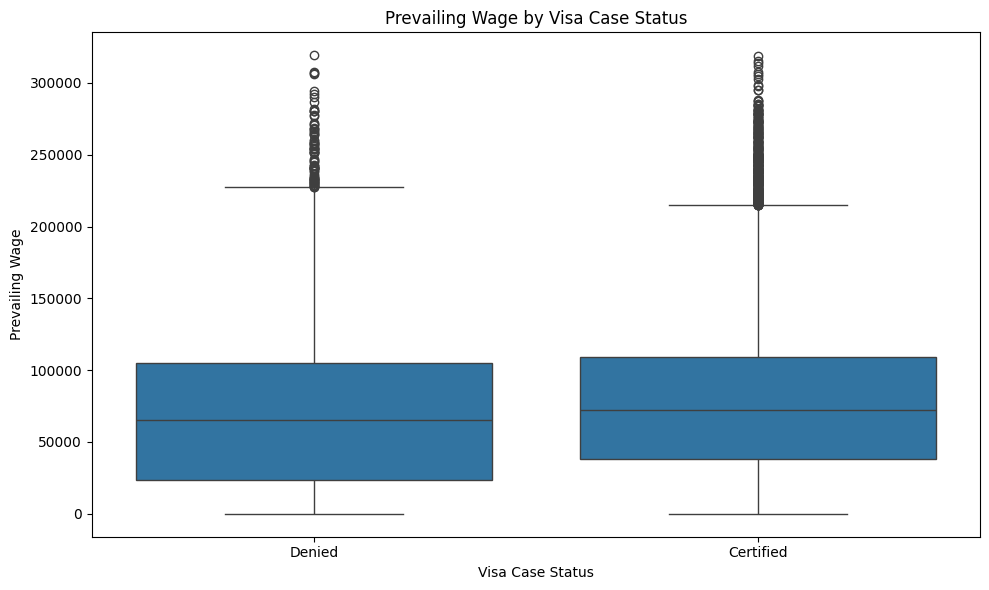

```python
plt.figure(figsize=(10, 6))

sns.boxplot(
    data=df,
    x='case_status',
    y='prevailing_wage'
)

plt.title('Prevailing Wage by Visa Case Status')
plt.xlabel('Visa Case Status')
plt.ylabel('Prevailing Wage')

plt.tight_layout()
plt.show()
```

#### Log-scale view

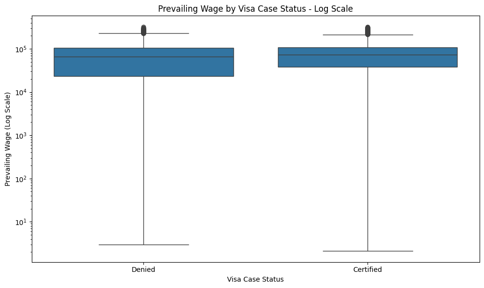

```python
plt.figure(figsize=(10, 6))

sns.boxplot(
    data=df,
    x='case_status',
    y='prevailing_wage'
)

plt.yscale('log')

plt.title('Prevailing Wage by Visa Case Status - Log Scale')
plt.xlabel('Visa Case Status')
plt.ylabel('Prevailing Wage (Log Scale)')

plt.tight_layout()
plt.show()
```

**Observation:**

The prevailing wage distributions for Certified and Denied applications are compared using both the original and logarithmic scales.

The presence of extreme wage observations will be investigated during the preprocessing stage before model development.

## 3.2 Categorical Variables vs Case Status

### Reusable function

```python
def categorical_target_analysis(data, feature, target='case_status'):

    # Percentage distribution within each category
    percentage_table = pd.crosstab(
        data[feature],
        data[target],
        normalize='index'
    ) * 100

    # Round values
    percentage_table = percentage_table.round(2)

    print(f"\nPercentage Distribution: {feature} vs {target}")
    display(percentage_table)

    # Plot
    ax = percentage_table.plot(
        kind='bar',
        stacked=True,
        figsize=(11, 6)
    )

    plt.title(
        f'{feature.replace("_", " ").title()} vs '
        f'{target.replace("_", " ").title()}'
    )
    plt.xlabel(feature.replace('_', ' ').title())
    plt.ylabel('Percentage of Applications')
    plt.xticks(rotation=45, ha='right')
    plt.legend(title='Case Status')

    plt.tight_layout()
    plt.show()

    return percentage_table
```

### 3.2.1 Continent vs Case Status

The continent of the employee is analyzed against visa case status to identify differences in certification and denial rates across geographical groups.

```
Percentage Distribution: continent vs case_status
```

| case_status continent | Certified | Denied |
| --- | --- | --- |
| Africa | 72.05 | 27.95 |
| Asia | 65.31 | 34.69 |
| Europe | 79.23 | 20.77 |
| North America | 61.88 | 38.12 |
| Oceania | 63.54 | 36.46 |
| South America | 57.86 | 42.14 |

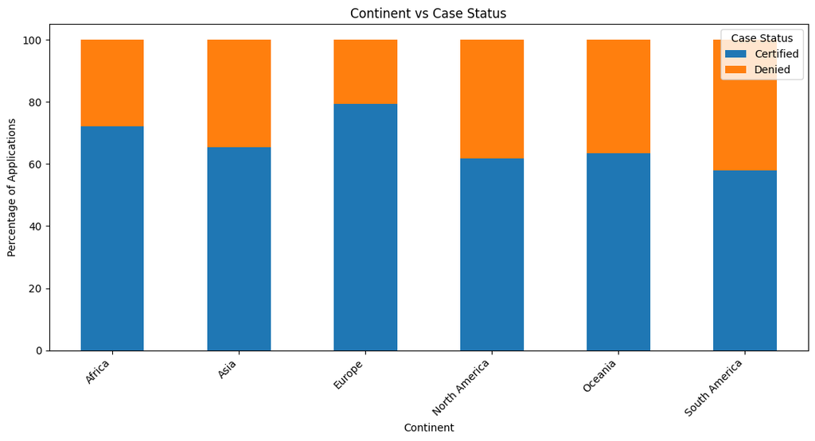

```python
continent_status = categorical_target_analysis(
    df,
    'continent',
    'case_status'
)
```

**Observation:**

The percentage distribution indicates that visa outcomes vary across the different continental groups.

This suggests that continent may contain useful predictive information for the classification model.